# 📊 Introdução à Estatística Descritiva com Python

Quando trabalhamos com dados, raramente conseguimos entender um conjunto de dados olhando apenas para os registros individuais.

Imagine um hospital com milhares de pacientes.

Cada paciente possui:

👤 idade  
⚖️ IMC  
❤️ pressão arterial  
🩺 diagnóstico  
💊 tratamentos

Se tentarmos analisar cada registro individualmente, rapidamente ficamos perdidos.

A estatística descritiva surge exatamente para resolver esse problema.

Ela fornece ferramentas para:

📊 resumir dados  
🔎 identificar padrões  
📈 compreender distribuições  
⚠️ detectar valores extremos

“Estatísticas sempre me fazem lembrar de um amigo que se afogou em um rio onde a profundidade média era somente de 1 metro.”

- WOODY HAYES -

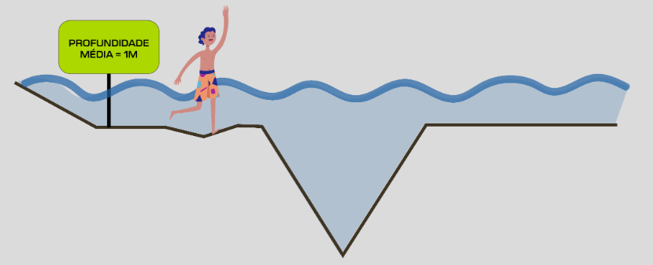

# 🧠 O que é Estatística Descritiva?

A estatística descritiva é o conjunto de métodos usados para **organizar, resumir e apresentar dados**.

Ela responde perguntas como:

📌 Qual é o valor típico de uma variável?

📌 Os valores são muito diferentes entre si?

📌 Existem valores extremos?

📌 Como os dados estão distribuídos?

Essas perguntas são fundamentais em qualquer análise de dados.

# 📊 Exemplos em saúde

Imagine que queremos analisar os dados de pacientes de uma unidade de saúde.

Algumas perguntas que a estatística descritiva ajuda a responder:

📌 Qual é a idade média dos pacientes?

📌 Qual é a distribuição da pressão arterial?

📌 Existe grande variação no IMC da população?

📌 Existem pacientes com valores muito extremos?

Essas perguntas são o primeiro passo para compreender um conjunto de dados.

## Exemplo: Mudança nas taxas de mortalidade

Existem muitas estatísticas descritivas que podemos calcular a partir de dados de saúde.

Para ilustrar isso, imagine que queremos analisar se **a mortalidade hospitalar para um determinado procedimento tem diminuído ao longo do tempo**.

Abaixo está um pequeno conjunto de dados com taxas de mortalidade observadas em diferentes anos.

```python
import pandas as pd

dados = pd.DataFrame({
    "Ano": [2000,2002,2004,2006,2008,2010,2012,2014],
    "Taxa_Mortalidade": [8.2,7.9,7.5,6.8,6.4,6.1,5.9,5.7]
})

dados
```

|  | Ano | Taxa_Mortalidade |
| --- | --- | --- |
| 0 | 2000 | 8.2 |
| 1 | 2002 | 7.9 |
| 2 | 2004 | 7.5 |
| 3 | 2006 | 6.8 |
| 4 | 2008 | 6.4 |
| 5 | 2010 | 6.1 |
| 6 | 2012 | 5.9 |
| 7 | 2014 | 5.7 |

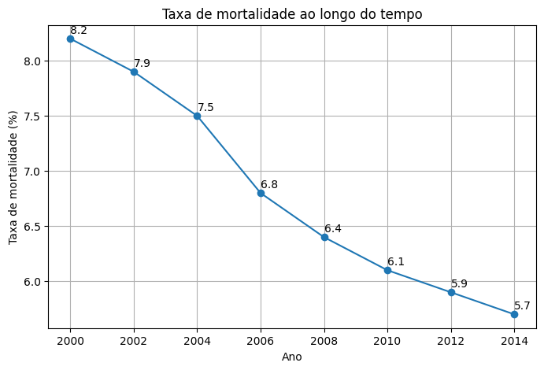

```python
import matplotlib.pyplot as plt

plt.figure(figsize=(8,5))

plt.plot(dados["Ano"], dados["Taxa_Mortalidade"], marker="o")

for i in range(len(dados)):
    plt.text(dados["Ano"][i], dados["Taxa_Mortalidade"][i]+0.05,
             dados["Taxa_Mortalidade"][i])

plt.title("Taxa de mortalidade ao longo do tempo")
plt.xlabel("Ano")
plt.ylabel("Taxa de mortalidade (%)")

plt.grid(True)

plt.show()
```

O gráfico permite visualizar a tendência das taxas de mortalidade ao longo do tempo.

Observa-se uma redução gradual da taxa de mortalidade entre os anos analisados.

Esse tipo de gráfico é um exemplo clássico de estatística descritiva, pois nos permite observar padrões e tendências nos dados.

No entanto, o gráfico não nos diz por que a mortalidade diminuiu. Para investigar causas, seriam necessárias análises adicionais.

Para entender melhor a mudança nas taxas de mortalidade, podemos dividir os dados em dois períodos:

- Período inicial
- Período mais recente

Uma maneira simples de fazer isso é separar os anos **antes e depois de um determinado ponto no tempo**.

```python
dados.groupby(dados.Ano <= 2006)["Taxa_Mortalidade"].mean()
```

| Ano | Taxa_Mortalidade |
| --- | --- |
| False | 6.025 |
| True | 7.600 |

**dtype:** float64

Esse cálculo mostra a **média da taxa de mortalidade em dois períodos diferentes**.

Esse tipo de análise é um exemplo de **estatística descritiva**, pois estamos apenas **resumindo e descrevendo os dados observados**.

Não estamos tentando explicar por que a mortalidade diminuiu, apenas descrevendo **o que aconteceu nos dados**.

# 📊 Diferença com Estatística Inferencial

Na análise descritiva, o foco está em descrever e resumir os dados por meio de medidas numéricas e representações gráficas. Já na análise inferencial, o objetivo é tirar conclusões gerais sobre a população a partir de amostras representativas, utilizando técnicas como estimativas e testes de hipóteses.

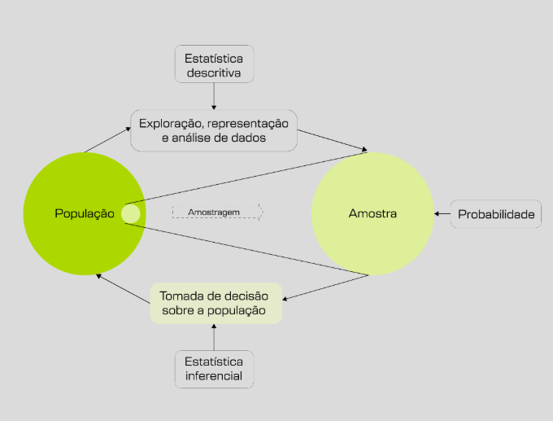

| Comparação | Análise descritiva | Análise inferencial |
| --- | --- | --- |
| **SIGNIFICADO** | A área da estatística é definida como estatística descritiva. Seu objetivo é fornecer uma descrição da população estudada. | Um tipo de estatística conhecida como estatística inferencial concentra-se em inferir informações sobre a população a partir de análises e descobertas de amostras. |
| **FUNÇÃO** | Para resumir a amostra, ela descreve os dados previamente conhecidos. | Faz um esforço para extrair uma amostra da população que vá além das evidências disponíveis. |
| **USO** | Explicar e descrever os dados coletados, tornando-os acessíveis para interpretação. | Estimar, prever ou testar hipóteses sobre fenômenos populacionais. |
| **MEDIDA TOMADA** | Organizar e visualizar os dados através de métricas como média, mediana, desvio padrão, entre outros. | Comparar dados, realizar testes de hipóteses e criar modelos preditivos. |
| **FORMA DE RESULTADO FINAL** | Apresentações gráficas (histogramas, tabelas, gráficos de dispersão) e numéricas (média, desvio padrão, etc.). | Resultados probabilísticos, como intervalos de confiança e significância estatística. |

# 🧭 O que veremos nas próximas aulas

A estatística descritiva envolve diferentes tipos de análises.

Nas próximas aulas vamos explorar:

📊 Medidas de tendência central  
(média, mediana, moda)

📉 Medidas de dispersão  
(variância, desvio padrão)

📈 Distribuição dos dados  
(histogramas)

📦 Identificação de outliers  
(boxplots)

🔗 Relação entre variáveis  
(correlação)

Cada uma dessas ferramentas ajuda a entender melhor um conjunto de dados.